# Posthumous Value of Digital Goods: Study Results

Author

Jamie C. Lee

Published

October 15, 2026

# Summary

**Aim.** Atasoy and Morewedge (2018) found that people value digital goods less than physical goods. This study asks whether considering a good’s value **after one’s lifetime** (as a family keepsake passed down to future generations), rather than **during one’s lifetime**, changes how much people are willing to pay for it, and whether it does so **more for digital goods**, narrowing the gap in valuation between digital and physical goods. The analysis is exploratory and tests three things: whether physical is valued more than digital overall, whether the after-lifetime (legacy) frame raises valuations overall, and whether the legacy frame narrows the physical–digital gap (the interaction).

- **Sample:** 1,332 participants who finished the survey (329–337 per condition). WTP answers are right-skewed (median $25, mean $37.42, max $500); only 1.8% said $0.
- **1. Physical vs. digital:** a random physical-condition participant offered more than a random digital-condition participant **57.4%** of the time (*p* < .001). Physical photos were valued about **28%** more (log ANOVA *p* < .001). This replicates the digital discount.
- **2. Legacy vs. lifetime:** a random legacy-frame participant offered more than a random lifetime-frame participant **59.8%** of the time (*p* < .001). The legacy frame raised WTP by about **38%** (log ANOVA *p* < .001).
- **3. Interaction:** the physical–digital gap was **smaller under the legacy frame** (physical offered more 61.2% of the time under lifetime vs. 54.3% under legacy). The change is significant in the rank-based test (*p* .026) and not significant in the log ANOVA (*p* .087).

Section 4 has the full results and Section 5 the full ANOVA table. Data quality checks are at the end (Section 7); no participants were excluded.

# 1 Study design

The study used a **2 (good: physical vs. digital) × 2 (frame: lifetime vs. legacy) between-subjects design**. Each participant was randomly assigned to one of four conditions, with Qualtrics keeping the four groups about equal in size. Everyone read the same scenario; only the two bracketed parts changed:

> Imagine that your extended family, including your parents, grandparents, and other relatives, has gathered for a family reunion. A professional photographer takes a photograph of the whole family together.

> After the reunion, you are given the option to purchase a **[physical / digital]** copy of the photograph. Imagine that you are choosing the photograph because **[purpose, see table]**.

> How much would you be willing to pay for the **[physical / digital]** photograph?

Table 1: The four conditions. The frame manipulation is the stated reason for buying the photograph.

| Condition | Good | Frame | Reason given for buying (exact wording) | n |
| --- | --- | --- | --- | --- |
| Physical × Lifetime | Physical | Lifetime (for oneself) | "...because you would like to keep it for yourself and be able to look back on it throughout your lifetime." | 337 |
| Physical × Legacy | Physical | Legacy (after one's lifetime) | "...because you would like it to become a family keepsake that can remain with your family after your lifetime and be passed down to future generations." | 333 |
| Digital × Lifetime | Digital | Lifetime (for oneself) | "...because you would like to keep it for yourself and be able to look back on it throughout your lifetime." | 329 |
| Digital × Legacy | Digital | Legacy (after one's lifetime) | "...because you would like it to become a family keepsake that can remain with your family after your lifetime and be passed down to future generations." | 333 |

**Procedure.** In order, participants:

1. Gave consent.
2. Were randomly assigned to a condition.
3. Read the scenario and entered their WTP (a page timer recorded how long they spent).
4. Explained their WTP in a few sentences.
5. Completed the durability and psychological ownership measures, with the order of the two counterbalanced at random.
6. Answered questions about children and grandchildren.
7. Were debriefed.

Table 2: Variables used in this report.

| Variable | Description | Measure | Role |
| --- | --- | --- | --- |
| good_type | Which copy of the photograph was offered | Physical / digital (randomly assigned) | Independent variable |
| value_frame | Reason given for buying | Lifetime / legacy (randomly assigned) | Independent variable |
| wtp | Willingness to pay for the photograph | Open-ended dollar amount (numbers only, ≥ $0) | Dependent variable |
| wtp_explain | Why they would pay that amount | Open-ended text | Data quality; themes |
| wtp_timer_first_click, _last_click, _page_submit, _click_count | Hidden page timer on the WTP page | Seconds; number of clicks | Data quality |
| perm_permanent, perm_stable, perm_durable, perm_lasting | "The [physical/digital] photograph is permanent / stable / durable / lasting" (adapted from Peña-Marín & Bhargave, 2016) | 1 = Strongly disagree to 7 = Strongly agree | Averaged into the durability index (exploratory) |
| own_degree, own_own, own_mine | "I would feel a very high degree of personal ownership of it / like I own it / like it is mine" (adapted from Peck & Shu, 2009; Shu & Peck, 2011) | 1 = Strongly disagree to 7 = Strongly agree | Averaged into the ownership index (exploratory) |
| followup_order | Which follow-up measure came first | Durability first / ownership first (randomly assigned) | Counterbalancing check |
| has_children, has_grandchildren, plan_children | Whether the participant has children or grandchildren, or plans to have children | Yes / no / not sure / prefer not to answer | Sample description |

# 2 Sample

## 2.1 How the sample size was determined

Before data collection, the sample size was set with a simulation-based power analysis (`wtp_power_analysis.html`). In plain terms:

1. **Invent realistic fake data.** We generated thousands of fake studies whose WTP answers looked the way we expected real answers to look: right-skewed, bunched on round numbers, a typical WTP of about $15 for the digital photo and $25 for the physical photo, and about 20% of digital answers (10% of physical) at $0. These values were our judgment of plausible prices, since no pilot data were available.
2. **Build in the effect we hoped to find.** In the fake data, the legacy frame raised digital WTP moderately (a legacy buyer outbid a lifetime buyer 60% of the time, about 63% higher WTP) and left physical WTP unchanged, so the physical–digital gap closed under the legacy frame.
3. **Run the planned tests on every fake study** and count how often they came out significant. A study counted as a success only if it detected both the interaction and the legacy effect for the digital photo.
4. **Find the smallest sample that succeeds 80% of the time.** That was about 300 participants per condition (1,200 total). With a 10% buffer for exclusions, we planned to recruit about 1,334 and obtained 1,332 complete responses.

**How the assumptions held up.** Two assumptions turned out differently:

- **Far fewer people said $0** (1.8% rather than about 20%), which *helps* power.
- **The legacy frame also raised physical WTP**, so the interaction was only about half the size planned for, which *hurts* power more.

A follow-up power analysis based on this study’s data (`wtp_power_analysis_from_study.html`) suggests about 950–1,600 participants per condition for a replication, depending on the analysis.

## 2.2 Participants

Table 3: Participants per condition and counterbalancing of the follow-up measures.

| Good | Frame | Durability first | Ownership first | Total |
| --- | --- | --- | --- | --- |
| Physical | Lifetime | 176 | 161 | 337 |
| Physical | Legacy | 170 | 163 | 333 |
| Digital | Lifetime | 167 | 162 | 329 |
| Digital | Legacy | 152 | 181 | 333 |
| Total |  | 665 | 667 | 1332 |

- **Survey length:** median completion time was **2.3 minutes** (middle 50%: 1.7–3.2 minutes).
- **Children:** 46.5% have children, 52.8% do not, 0.8% preferred not to answer. Among parents, 17.9% have grandchildren. Among non-parents, 26.2% plan to have children and 25.3% are not sure.

# 3 WTP descriptives

Table 4: Willingness to pay (in dollars) by condition.

| Condition | n | % $0 | Mean | SD | Median | Middle 50% | 90th pct. | Max |
| --- | --- | --- | --- | --- | --- | --- | --- | --- |
| Physical × Lifetime | 337 | 1.5% | $34.80 | $43.92 | $25 | $15–$40 | $60 | $500 |
| Physical × Legacy | 333 | 1.5% | $47.55 | $54.56 | $25 | $20–$50 | $100 | $500 |
| Digital × Lifetime | 329 | 2.4% | $26.47 | $37.58 | $20 | $10–$30 | $50 | $500 |
| Digital × Legacy | 333 | 1.8% | $40.77 | $47.98 | $25 | $15–$50 | $100 | $300 |

The **mean** is pulled up by a small number of very large answers (up to $500), so it is consistently higher than the **median**. That is why the planned tests use ranks (“who offered more”) rather than averages.

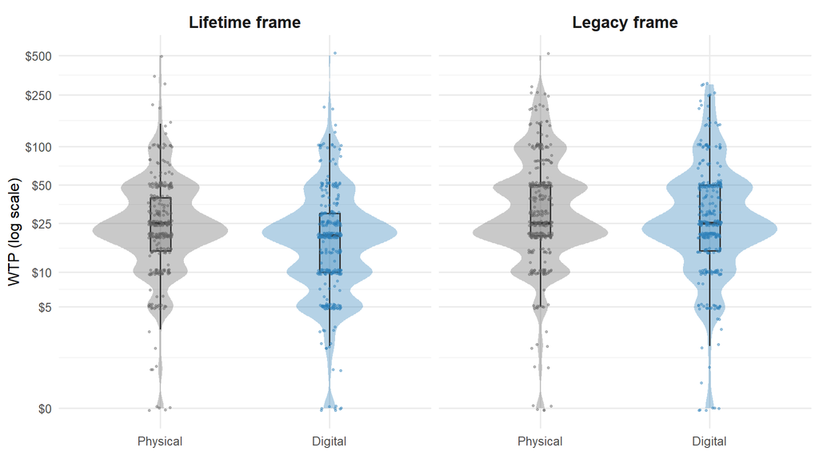

Figure 1: Every participant’s WTP (dots), the distribution (shaded violin), and a box showing the median and middle 50%, arranged to compare physical vs. digital within each frame. The vertical axis is on a log scale so that the many answers between $5 and $100 are not squashed by the few very large ones.

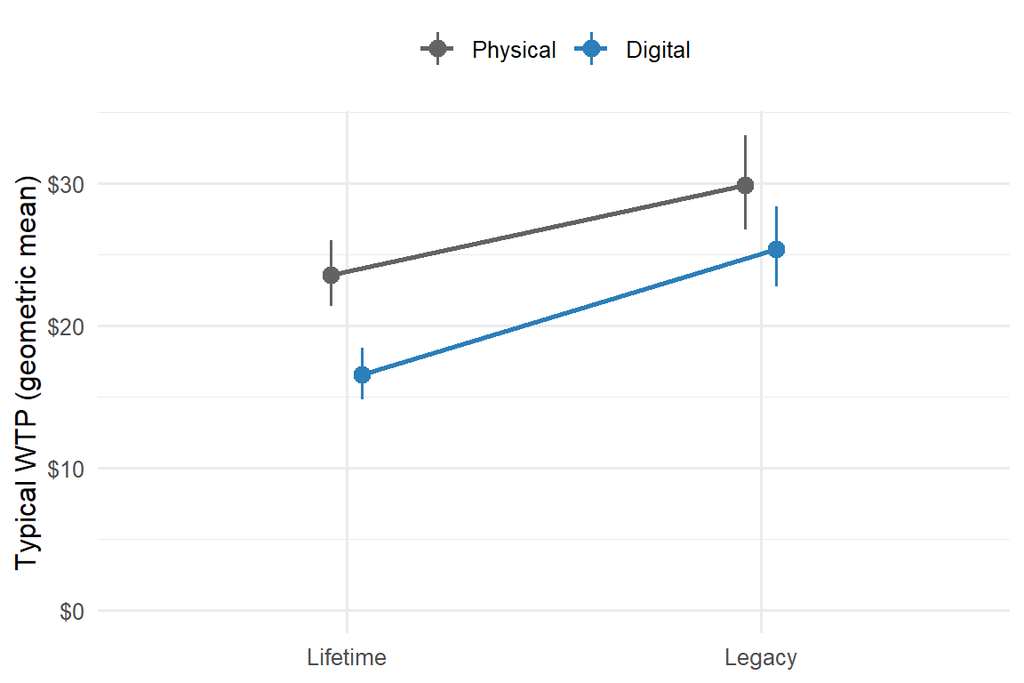

Figure 2: Typical WTP by condition with 95% confidence intervals. ‘Typical’ is the geometric mean (the average on the log scale, converted back to dollars), which is less distorted by a few very large answers than the ordinary mean. Medians are not shown because answers bunch so heavily on $20 and $25 that the medians barely move. The vertical distance between the two lines is the physical–digital gap; lines that move closer together under the legacy frame mean the gap shrank.

**Round numbers dominate.** The six most common answers ($20, $25, $50, $10, $5, $15) account for 66.7% of all responses. Many ties are expected with WTP and are handled by the rank-based tests.

# 4 Main analyses

Three tests, each run two ways:

- **Rank-based (primary):** how often a participant in one group offered more than a participant in the other (probability of superiority, PS; 50% = no difference). This uses who outbid whom, so a few very large answers cannot dominate.
- **2×2 ANOVA on log(WTP + 1):** the familiar analysis. The log shrinks very large answers; estimates are converted to approximate percentage differences in WTP.

Table 5: The three tests. Rank-based tests: Wilcoxon rank-sum for the two overall comparisons; for the interaction, a z-test on the change in the physical–digital PS from the lifetime to the legacy frame (DeLong standard errors). ANOVA columns: estimated differences from a 2×2 model on log(WTP + 1), as approximate percentage differences.

| Test | Rank-based estimate [95% CI] | p (rank) | ANOVA: ≈ % difference [95% CI] | p (ANOVA) |
| --- | --- | --- | --- | --- |
| 1. Physical vs. digital (overall) | 57.4% [54.4%, 60.5%] | < .001 | 28% [16%, 42%] | < .001 |
| 2. Legacy vs. lifetime (overall) | 59.8% [56.7%, 62.8%] | < .001 | 38% [24%, 53%] | < .001 |
| 3. Interaction: change in the physical–digital gap (lifetime gap − legacy gap) | 6.9 pts [0.8, 13.0] | .026 | 20% [-3%, 47%] | .087 |

How to read each row:

- **Row 1:** PS = probability a physical-condition participant offered more than a digital-condition participant. ANOVA: how much more physical was valued.
- **Row 2:** PS = probability a legacy-frame participant offered more than a lifetime-frame participant. ANOVA: how much more legacy was valued.
- **Row 3:** how much the physical–digital gap shrank under the legacy frame. In the rank version, the drop in the physical-over-digital PS; in the ANOVA, the drop in physical’s percentage premium.

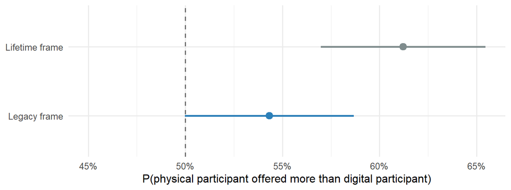

Figure 3: The interaction, pictured: probability that a physical-condition participant offered more than a digital-condition participant, within each frame (95% CIs). The dashed line at 50% means no difference. The interaction test asks whether the two estimates differ.

**In plain terms:**

1. **Physical photos were valued more than digital ones** (57.4% of comparisons; about 28% more), replicating the digital discount.
2. **The legacy frame raised WTP** overall (59.8% of comparisons; about 38% more).
3. **The legacy frame shrank the digital discount**, but how firmly depends on the analysis. The physical-over-digital advantage dropped from 61.2% (lifetime) to 54.3% (legacy). That change is significant in the rank-based test (*p* .026) and not significant in the log ANOVA (*p* .087). Treat it as **promising but not yet conclusive**.

**What the interaction does and does not show.** Under the legacy frame the gap was smaller, but physical was still valued somewhat more (54.3% of comparisons, *p* .052; about 17% more in the log ANOVA, *p* .035). So the legacy frame **narrowed** the digital discount. It did not reverse it, and a non-significant gap would not by itself show that the two are valued the same.

## 4.1 Follow-up comparisons

These break the 2×2 into its four simple comparisons, to show where the interaction comes from.

Table 6: Simple comparisons (rank-based, two-sided Wilcoxon tests), with the log-ANOVA percentage difference for reference.

| Comparison | PS (95% CI) | p (rank) | ANOVA: ≈ % difference | p (ANOVA) |
| --- | --- | --- | --- | --- |
| Lifetime frame: physical vs. digital | 61.2% (57.0%–65.5%) | < .001 | 40% | < .001 |
| Legacy frame: physical vs. digital | 54.3% (50.0%–58.7%) | .052 | 17% | .035 |
| Physical: legacy vs. lifetime | 57.1% (52.8%–61.4%) | .001 | 26% | .002 |
| Digital: legacy vs. lifetime | 62.8% (58.6%–67.0%) | < .001 | 51% | < .001 |

**Where the interaction comes from.** The legacy frame raised WTP for **both** goods (digital 62.8%, physical 57.1%), but more for digital, so the gap narrowed.

# 5 Full ANOVA table

Table 7: 2×2 ANOVA on log(WTP + 1) (Type III sums of squares, effect coding).

| Term | Sum Sq | df | F | p |
| --- | --- | --- | --- | --- |
| Good (physical vs. digital) | 20.39 | 1 | 22.10 | < .001 |
| Frame (legacy vs. lifetime) | 34.06 | 1 | 36.90 | < .001 |
| Good × Frame | 2.70 | 1 | 2.93 | .087 |
| Residuals | 1,225.64 | 1328 |  |  |

# 6 Durability and ownership (exploratory)

Two questions: do **durability** and **psychological ownership** differ between the physical and digital photo, and do they differ between the lifetime and legacy frames?

## 6.1 Building the two indices

**Do the seven items form two distinct indices?** Yes.

- **Number of factors.** A parallel analysis (which compares the data with random noise) suggests **2 factors**.
- **Item loadings.** In an exploratory factor analysis, every item loads strongly on its intended factor and near zero on the other (table below).
- **Model fit.** A confirmatory two-factor model fits very well (CFI = 0.994, RMSEA = 0.053, SRMR = 0.023). Forcing all seven items onto one factor fits poorly (CFI = 0.542, RMSEA = 0.464).
- **The two constructs are related but distinct** (correlation between factors = 0.48).

Table 8: Exploratory factor analysis (maximum likelihood, oblique rotation): loadings of each item on the two factors.

| Item | Durability | Ownership |
| --- | --- | --- |
| Permanent | 0.79 | 0.00 |
| Stable | 0.84 | 0.04 |
| Durable | 0.89 | -0.07 |
| Lasting | 0.86 | 0.05 |
| Very high degree of personal ownership | 0.02 | 0.92 |
| Feel like I own it | 0.00 | 0.96 |
| Feel like it is mine | -0.01 | 0.96 |

Table 9: Measurement invariance. Each row adds constraints: the same factor structure (configural), the same loadings (metric), the same item intercepts (scalar). A drop in CFI of no more than .01 at each step is the usual standard for ‘the items work the same way across groups.’ Scalar invariance is what justifies comparing group means.

| Comparison | Level | CFI | Change in CFI | RMSEA |
| --- | --- | --- | --- | --- |
| Physical vs. digital | Configural | 0.996 | — | 0.041 |
| Physical vs. digital | Metric | 0.996 | 0.000 | 0.039 |
| Physical vs. digital | Scalar | 0.991 | -0.005 | 0.055 |
| Lifetime vs. legacy | Configural | 0.995 | — | 0.050 |
| Lifetime vs. legacy | Metric | 0.995 | 0.000 | 0.044 |
| Lifetime vs. legacy | Scalar | 0.996 | 0.000 | 0.040 |

**The items work the same way in every condition.** The largest drop in CFI is -0.005, within the .01 standard, so comparing the conditions’ scores is legitimate.

**Factor scores or simple averages?** Both were computed. They are nearly identical: r = 0.994 for durability and r = 0.998 for ownership. The indices below use the **simple average of the items** (on the original 1–7 scale; α = 0.91 and 0.96), which is easier to interpret and compare across studies. As a check, the tests are also run on the factor scores.

## 6.2 Do the indices differ by good and by frame?

Table 10: Durability and ownership indices (1–7) by condition: mean (SD).

| Condition | Durability | Ownership |
| --- | --- | --- |
| Physical × Lifetime | 5.56 (1.11) | 6.42 (0.76) |
| Physical × Legacy | 5.52 (1.09) | 6.22 (0.95) |
| Digital × Lifetime | 5.37 (1.31) | 5.59 (1.35) |
| Digital × Legacy | 5.44 (1.36) | 5.73 (1.28) |

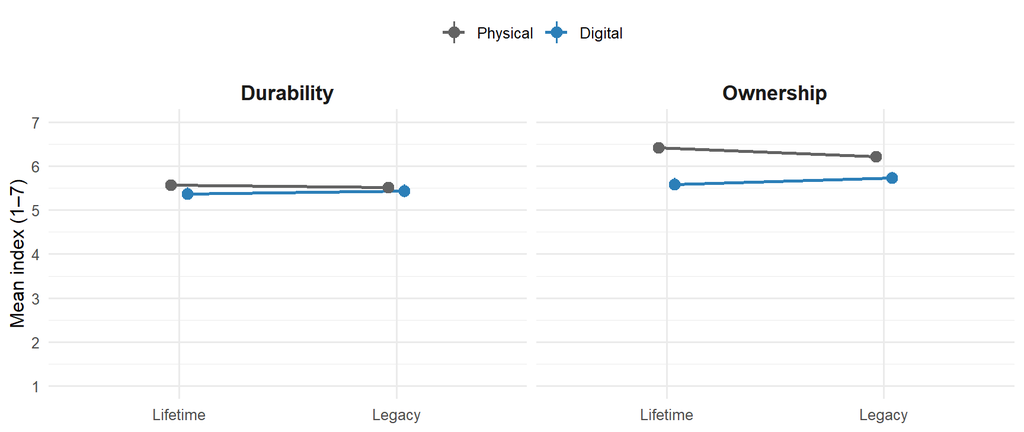

Figure 4: Mean durability and ownership indices with 95% confidence intervals.

Table 11: Tests run three ways: a 2×2 ANOVA on the averaged index (primary), a rank-based Wilcoxon test (probability that a participant in the first group scored higher than one in the second), and the same ANOVA on factor scores.

| Index | Effect | Mean difference | p (ANOVA) | Rank PS | p (rank) | p (factor scores) |
| --- | --- | --- | --- | --- | --- | --- |
| Durability | Physical vs. digital | +0.14 | .043 | 51.0% | .510 | .008 |
|  | Legacy vs. lifetime | +0.01 | .888 | 50.8% | .613 | .806 |
|  | Good × frame | — | .379 | — | — | .259 |
| Ownership | Physical vs. digital | +0.66 | < .001 | 66.2% | < .001 | < .001 |
|  | Legacy vs. lifetime | -0.03 | .644 | 48.6% | .355 | .623 |
|  | Good × frame | — | .005 | — | — | .006 |

**In plain terms:**

- **Ownership: physical is clearly higher.** People expected to feel much more ownership of a physical photo (6.32 vs. 5.66 on the 1–7 scale; all three tests *p* < .001). There was **no overall difference between frames** (*p* .644), but there **was an interaction** (*p* .005): the legacy frame slightly *lowered* ownership for the physical photo (6.42 → 6.22) and slightly *raised* it for the digital photo (5.59 → 5.73). This is the same direction as the WTP pattern, where the legacy frame narrowed the physical–digital gap.
- **Durability: at most a small, fragile difference.** Physical was rated slightly more durable (5.54 vs. 5.40), but whether this is significant depends on the method: *p* .043 on the averaged index, *p* .008 on factor scores, and *p* .510 with the rank test. Treat it as **not reliably different**. There was no frame effect and no interaction.
- **Ceiling effects.** 34.8% of participants gave the maximum ownership score (7) and 12.6% the maximum durability score, so these scales may understate real differences near the top.
- **Question order did not matter.** Scores did not differ by whether durability or ownership was asked first (*p* .253 and .682).

# 7 Data quality checks

No participants were excluded from any analysis. These checks are reported for transparency.

## 7.1 Open-ended explanations

Table 12: Response quality and review flags by condition.

| Condition | n | Median words | Low effort | Off topic / nonsense | Misread format | Rejects premise | Text conflicts with WTP | Sensitive disclosure |
| --- | --- | --- | --- | --- | --- | --- | --- | --- |
| Digital × Legacy | 333 | 27 | 12 | 0 | 8 | 5 | 0 | 4 |
| Digital × Lifetime | 329 | 25 | 17 | 0 | 10 | 8 | 3 | 1 |
| Physical × Legacy | 333 | 27 | 18 | 0 | 1 | 5 | 0 | 0 |
| Physical × Lifetime | 337 | 27 | 18 | 0 | 1 | 6 | 0 | 4 |
| Total | 1332 | 26 | 65 | 0 | 20 | 24 | 3 | 9 |

**Bottom line:** 0 responses (0.0%) were off topic or nonsensical, so there is little sign of random answering. 65 (4.9%) were low effort (a generic phrase such as “seems fair” with no reason). In total, 119 responses (8.9%) carry at least one flag worth a look.

**NoteDetails: how responses were coded, coding reliability, themes, and flagged responses**

**How these were coded.** Every one of the 1,332 explanations was read and coded against a fixed codebook (see the appendix) by AI coders working from the full text plus each person’s condition and WTP. Keyword rules were not used to assign codes, because they cannot tell, for example, a correct contrast (“it’s not even a printed copy”) from a misreading (“I’d frame it on my wall” in the digital condition). To check consistency, a second, independent coder re-coded a random 150 responses (Table 13). **Treat these codes as a careful first pass for you to verify, not as final judgments.** Every flagged response is listed below with its full text.

Table 13: Agreement between the primary coding and an independent second coder on a random subsample. Cohen’s kappa corrects for chance agreement; it is unstable (or undefined) when a code is very rare.

| Code | Agreement | Kappa | Flagged (coder 1 / coder 2) |
| --- | --- | --- | --- |
| quality | 99.3% | 0.92 | 7 / 6 |
| misread_format | 99.3% | 0.00 | 1 / 0 |
| rejects_premise | 100.0% | 1.00 | 3 / 3 |
| wtp_text_conflict | 100.0% | n/a | 0 / 0 |
| sensitive | 100.0% | 1.00 | 1 / 1 |
| theme: free_alternative | 99.3% | 0.97 | 18 / 19 |
| theme: durability | 98.7% | 0.88 | 10 / 8 |
| theme: legacy | 98.7% | 0.90 | 12 / 10 |
| theme: sentimental | 96.0% | 0.91 | 53 / 55 |
| theme: professional_quality | 98.7% | 0.97 | 61 / 61 |
| theme: price_norms | 96.0% | 0.92 | 79 / 79 |
| theme: sharing_cost | 100.0% | 1.00 | 7 / 7 |
| theme: printing | 98.7% | 0.92 | 15 / 13 |
| theme: format_preference | 97.3% | 0.79 | 11 / 9 |
| theme: uncertainty | 99.3% | 0.94 | 8 / 9 |

#### Themes in people’s reasoning

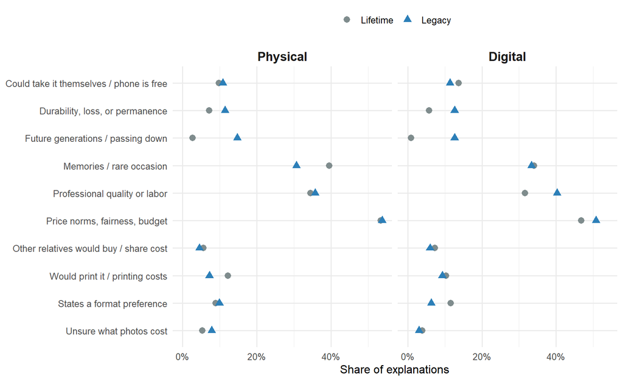

Figure 5: Share of explanations mentioning each theme, by condition. A response can mention several themes.

**Patterns worth noting:**

- **“I could take it myself”** reasoning appears in 12.5% of digital explanations vs. 10.3% of physical ones, a small difference.
- **Durability or loss** comes up in 9.2% (digital) vs. 9.3% (physical) of explanations, essentially the same. When people mention it, they speak directly to the mechanism the durability measure is meant to capture, so these responses are worth reading in the table below.
- **Future generations** are mentioned by 13.7% of legacy-frame participants vs. 1.8% of lifetime-frame participants, suggesting the framing was noticed.

#### Flagged responses

##### Off topic or nonsensical (0)

None.

##### Possibly misread which format they were buying (20)

| ResponseId | Condition | WTP | Explanation | Coder note |
| --- | --- | --- | --- | --- |
| R_6PR93wBQ0YqIUUF | Digital × Legacy | $60.00 | I feel a family reunion is very rare for my family. To receive a professional photograph of all of the current generations of my family would be wonderful. I would want my children to be able to share… | Digital condition but prices a dozen same-sized prints |
| R_1feNhfu4zjM9Z2Q | Digital × Legacy | $5.00 | It seems reasonable for a quality print-out. Normally I would just take a photo like this myself. | Digital condition but values it as a “quality print-out” |
| R_7RxwimlB3AEu7UQ | Digital × Lifetime | $50.00 | If the photographer is a professional, I think that it is reasonable to be charged 50 dollars for a keepsake like this. I envision that the product would be framed, allowing me to immediately enjoy it… | Digital condition but envisions receiving a framed product |
| R_5Vq18hEvQUvmViD | Digital × Lifetime | $45.00 | That’s generally what I would pay the most for a print considering copyright and usage and cost to the photographer. | Digital condition but describes what they’d pay for a print |
| R_5JmcOHUxF8PsadZ | Digital × Lifetime | $100.00 | Assuming it was a high quality portrait picture that be willing to show my mantle I would think $100 would not be outrageous | Digital condition but describes displaying portrait on mantle |
| R_69wKyzL1apwP9Sx | Digital × Lifetime | $20.00 | It really depends on the form I end up with. If it’s just a downloadable copy that I have send to a company to make a hard copy I’m not sure how much I would pay. For 20.00 I expect a hard copy. I wou… | Digital condition but expects a hard copy to display for $20. |
| R_38UJ8vKi7TWdizA | Digital × Legacy | $20.00 | The $20 that I indicated seems like a good price for a nice professionally done, glossy photo. I assume that I can take photos at any time of my family with my phone, and print at home or local Walgre… | Digital condition but prices it as a professionally done glossy photo |
| R_7gRXeZNuQcPcHL3 | Digital × Legacy | $30.00 | I think it would probably be a good quality photo, and if I purchase it I might also be able to customize it or get a frame. So I think its a fair price. I also value this photograph and want to buy s… | Digital condition but expects purchase may include a frame. |
| R_7Are0vijp7O5imJ | Physical × Lifetime | $20.00 | Its a reasonable price for a print out and digital copy | Physical condition but thinks they get print and digital copy |
| R_1JEGwxRW5EnSump | Digital × Lifetime | $20.00 | I thought that $20 seemed like a fair price. Pays for the printing process and paper. I’d also be willing to pay more because it’s a special photo. | Digital condition but says price covers printing process and paper |
| R_3im6tJe24vuK0GN | Digital × Lifetime | $10.00 | I assume that I already paid for the photographer’s time, so I would not pay much additional money for a print. | Digital condition but refers to paying for a print |
| R_6Y4mzTykyaQhuBk | Digital × Lifetime | $25.00 | It just sounds like an appropriate amount for a precious photo that I like and want to put in a frame. | Digital condition but wants to put the photo in a frame |
| R_5EaqcHLh2FHdGk3 | Physical × Legacy | $25.00 | I’m assuming here that the photographer would give us a digital version of the photo and the physical version would be an add-on? So, I would be willing to pay $25 for the photographer’s physical copy… | Physical condition but assumes a digital version is also given |
| R_39aVslAh6hTYiis | Digital × Legacy | $75.00 | A picture like that from a professional photographer would be something to be able to keep and hang up to have for a lifetime. It would be money well spent. | Digital condition but describes hanging the photo up. |
| R_6nw36MAEd850jso | Digital × Lifetime | $25.00 | I would want something to remember this moment by. Having a physical copy is worth $25 to me. | Digital condition but says having a physical copy is worth $25 |
| R_6lRM3Rt5sj9ndeY | Digital × Legacy | $25.00 | The photo is from a professional photographer and my assumption is that they would keep negatives on file should I ever need extras. The quality of the photograph and the paper on which it’s printed w… | Digital condition but describes negatives and print paper quality |
| R_3mmiZ3VtyARg1KF | Digital × Legacy | $75.00 | It’s a photograph of my family made by a professional photographer. The photograph will probably be large enough and framed professionally to hang on a wall. | Digital condition but expects large, professionally framed photo to hang |
| R_38raCZr5NqMPLVL | Digital × Lifetime | $10.00 | I would be willing to pay for the print because it is something that I wanted to have as a memory of the family. | Digital condition but says they would pay for “the print”. |
| R_3Ooz2vXp3S3AOPq | Digital × Legacy | $30.00 | It’s a digital copy of the photography, so there’s nothing physical to display or collect unless I do the printing work myself. I expected I purchased a nice physical quality already in the scenario a… | Digital condition; assumes a physical print already purchased too |
| R_6vdmcfRVpG6f5hG | Digital × Lifetime | $18.00 | I think it is a fair amount as I would not get a large print | Digital condition but refers to size of print received |

##### Rejected the premise of the scenario (24)

| ResponseId | Condition | WTP | Explanation | Coder note |
| --- | --- | --- | --- | --- |
| R_1YgFfBBEcP664MQ | Physical × Legacy | $0.00 | I am not interested in keeping pictures for whatever event or circumstance | Not interested in keeping pictures at all; pays nothing |
| R_7378gVpPRTUHbmI | Physical × Lifetime | $5.00 | I do’nt want it but you made a scenario in which I have to want it. | Says they do not want it; scenario forces wanting it |
| R_7ZWZrFL3ycFEIsp | Digital × Legacy | $0.00 | I don’t like taking photographs and view photos as having little to no value. | Dislikes photos, sees little to no value in them |
| R_6Pbu6w37OJPyHBL | Digital × Lifetime | $25.00 | It seems reasonable. I have no family and never purchased anything similar, so I have no idea how they are priced. | States they have no family; scenario doesn’t apply |
| R_7qvKroE9b0EuH1H | Digital × Lifetime | $0.00 | I don’t need a photo, I have memories. | Says they don’t need a photo; has memories |
| R_74DQwdT5ElXdKrT | Physical × Lifetime | $0.00 | I hate photographs that include me in them and don’t want to pay to have one of them around. I can’t reallys tand looking at myself. | Hates photos of self; does not want one at all |
| R_1rIgTX9qHFGwB0W | Physical × Legacy | $0.00 | I am not close to my family and therefore I will not pay anything to buy the photo. | Not close to family; would not pay anything |
| R_7CCPcSj9l1CjeNJ | Physical × Lifetime | $0.00 | I don’t have interest in owning a physical photograph of myself and my family. I don’t like looking at or keeping photographs. So I would not be willing to pay any amount of money for an item I do not… | Has no interest in owning photos; would pay nothing |
| R_1e3kznzVYdpWcng | Digital × Legacy | $0.00 | If I’m going to pay for something it better have a physical presence. I don’t buy anything that’s virtual. | Says they never buy anything virtual; would not buy digital. |
| R_5V1Et8v6DbHUawF | Digital × Lifetime | $0.00 | I would not be willing to pay for a digital photograph when I could just take a picture of myself and use SI to modify it any way I want. | Would not buy; would take own photo and edit with AI |
| R_1Pl10PQADnw5Ilz | Digital × Lifetime | $5.00 | It’s digital, so it’s not like producing it involves a lot of materials like standard photography. I am not inclined to pay much for a digital copy. I probably wouldn’t bother buying it at all. | Says they probably wouldn’t bother buying it at all. |
| R_3VgBEZG1QOGT3G1 | Digital × Lifetime | $0.00 | i don’t like photographs. i wouldn’t pay for it. | Dislikes photographs; would not pay for it at all |
| R_71py1ddGPTrEI2n | Digital × Lifetime | $10.00 | Honestly I wouldnt pay for it at all because I dont care for pictures much. Assuming I had to ten bucks seems fair to me. | Says would not pay at all; doesn’t care for pictures |
| R_1masT1KNKGe1kfn | Physical × Legacy | $0.00 | I myself am a professional photographer. In no way would I ever rely on someone else to create a print for me, I would do it myself. | Professional photographer; would never buy a print, would make own |
| R_6JFnqz2ZRSnWTsl | Physical × Lifetime | $1.00 | I would pay a small amount due to not wanting a copy of the photo, it would not be something I would want. | Says they would not want a copy of the photo. |
| R_5eagelDgFwgLMUw | Physical × Legacy | $0.00 | I would never be in this situation. | Says they would never be in this situation. |
| R_5NyIkVnVQEpGugo | Physical × Legacy | $0.00 | I would not be willing to pay for the physical photograph because a digital copy is all I need. | Would not pay for physical photo; digital copy is all they need. |
| R_5kohLXUihO9FaS6 | Digital × Legacy | $10.00 | I would have a non family member take my own picture. just to have same pic as everyone else. thinking back wouldn’t buy it if had to say yes or no | Says on reflection they would not buy it in a yes/no choice. |
| R_6bQJS5EJBc2p0xb | Physical × Lifetime | $0.00 | Because I am not a fan of physical photographs, I wouldn’t pay anything for it. I would pay for digital. | Would not pay anything for physical; not a fan of prints. |
| R_7Nn3yE0qCeVldxI | Digital × Lifetime | $0.00 | Personally, being around my whole extended family sounds like a nightmare and I would not like to look back on it. | Would not want photo; being with extended family sounds like a nightmare. |
| R_72jLAiIQyf50Uwh | Digital × Lifetime | $0.00 | I wouldn’t be willing to pay for that at all. If I want pictures of my family members, I can take my own for free, and I would also prefer candid photographs rather than a posed professional photograp… | Would not pay at all; can take own photos |
| R_3ivYvBozbDqAqLy | Physical × Lifetime | $0.00 | Quite a few family members of mine are deceased. A lot of my family members I do not particularly like. So, I would not pay any money for the photograph. | Would not pay; many relatives deceased, dislikes family members |
| R_7rdc0P1BxW0sgd0 | Digital × Legacy | $0.00 | I would not be willing to pay anything, zero, because why on earth would a pro photographer be at my family reunion but then charge extra on top of whatever they are almost surely charging for simply … | Calls scenario bizarre; would pay nothing, objects to being charged |
| R_75AOMo5WRwelPGq | Digital × Legacy | $0.00 | My blood relations are cruel to me and gaslight and fucked up shit like that all the time | Describes cruel, gaslighting family; pays nothing |

##### Explanation conflicts with the WTP entered (3)

| ResponseId | Condition | WTP | Explanation | Coder note |
| --- | --- | --- | --- | --- |
| R_3L55bgq2tnLmH6c | Digital × Lifetime | $10.00 | A digital photograph capturing multiple generations of my extended family holds strong sentimental value that lasts a lifetime. Paying $15–$20 reflects the professional effort of the photographer whil… | Text says paying $15-$20 but entered 10 |
| R_5xVO6IXmOJg3ufZ | Digital × Lifetime | $10.00 | Because it can easily replicated with a simple ctrl c + v. The only reason I’m paying anything for it is because a professional took it. Now that I think about it, I should’ve entered 0. Someone else … | Says should have entered 0 but entered 10 |
| R_1KOv9pWl0TQuXvI | Digital × Lifetime | $5.00 | I feel that a digital photograph should not be expensive. In fact, I feel $5 is too much. I truly feel a print is much more worth a higher price and would pay less than $5 for digital. | Says would pay less than $5 but entered 5 |

##### Sensitive disclosures (9)

| ResponseId | Condition | WTP | Explanation | Coder note |
| --- | --- | --- | --- | --- |
| R_7mBW6CKGkO25b7b | Digital × Legacy | $75.00 | Well, truly that would be priceless to me so I would probably spend even more on such a pic. I lost all my grandparents when I was young so I can’t even imagine being lucky enough to have such a famil… | Discloses losing all grandparents when young |
| R_5R9g5h5pMXeH8wr | Digital × Lifetime | $35.00 | As I get older and I have lost family members in death, I appreciate the importance of preserving family memories such as by photos. Since it’s a digital photo in this case, it seems the expense shoul… | Mentions losing family members to death |
| R_6pyxaXelP1HVd30 | Digital × Legacy | $25.00 | After my dad passed away a few years ago, I’ve noticed that I don’t have a lot of pictures of him. I wish I had more pictures of the whole family together. My mom is still alive and I would like to ha… | Discloses father passed away a few years ago. |
| R_5m3Ru9RNBpUVUMu | Digital × Legacy | $2.00 | I don’t think it would be worth much, to me, and I don’t have that much money. My extended family is not great and I don’t particularly want reminders of them around. | Extended family ‘not great’; doesn’t want reminders of them; limited money |
| R_6gLyQ8tk9wzF7Xt | Physical × Lifetime | $50.00 | My parents and grandparents are all gone. I know how fast time passes, so if they were really still here, the picture would be priceless. | Discloses that parents and grandparents have all died. |
| R_3fkidx7MQrqMLly | Physical × Lifetime | $40.00 | I don’t really have much family anymore so it would be valuable to me to have a picture of us all together. It would be the only photo I’d hang on my wall to remember the past. | Says they don’t have much family anymore |
| R_3ivYvBozbDqAqLy | Physical × Lifetime | $0.00 | Quite a few family members of mine are deceased. A lot of my family members I do not particularly like. So, I would not pay any money for the photograph. | Would not pay; many relatives deceased, dislikes family members |
| R_6ZBLEUuPGg4qane | Physical × Lifetime | $99.00 | I think a well done photograph that has my whole family in it would be a great keepsake. We had one done at an Aunts wedding that I still see in a couple of my Aunts houses and the photo is one of the… | Mentions multiple family members who have died |
| R_75AOMo5WRwelPGq | Digital × Legacy | $0.00 | My blood relations are cruel to me and gaslight and fucked up shit like that all the time | Describes cruel, gaslighting family; pays nothing |

##### Low effort (generic, no reason given) (65)

| ResponseId | Condition | WTP | Explanation | Coder note |
| --- | --- | --- | --- | --- |
| R_5n0IUlRid36QFXj | Digital × Lifetime | $10.00 | it seems fair | Only “it seems fair,” no reason |
| R_5OQbAy4peZYgY7M | Physical × Legacy | $18.00 | Good price for a family photo | Only “good price for a family photo,” no reason |
| R_1QiXHtwyN7C7zPP | Digital × Lifetime | $20.00 | I feel like it’s a good amount for most things. It’s too little but it’s also not too much. I feel like it’s a fair price for a photo. | Generic fair-price statement with no actual reason |
| R_7TtkGQeux9YyUMO | Physical × Legacy | $150.00 | I think it’s a reasonable amount for one picture. | Only “reasonable amount for one picture,” no reason |
| R_6woamFkPvieqF0N | Physical × Lifetime | $25.00 | I would pay that amount because I feel like its a fair amount for whats being given. But its not too low of an amount either. | Generic: fair amount, not too low; no reason |
| R_2g7tFdhidg88t2i | Physical × Legacy | $3.00 | It’s worthy a nice photo | Only “worthy a nice photo,” no actual reason |
| R_5I6RFY6DxWQHsIx | Physical × Lifetime | $10.00 | That seems like a fiar price. | Only says it seems a fair price; no reason. |
| R_62zEbgMFdm6hvjw | Physical × Lifetime | $25.00 | I just felt like that is the proper amount for a photograph. | Only says amount feels proper; no actual reason |
| R_1rdDebwuDihKhpL | Physical × Legacy | $20.00 | That was the first thing that popped into my head. | First number that came to mind; no reason |
| R_571rFtuMV1uPk7T | Physical × Lifetime | $50.00 | I just thought it is a reasonable price for such a photograph. | Only “reasonable price,” no actual reason |
| R_1d6JqYqOIQCWoSt | Digital × Lifetime | $25.00 | because thats whats its worth | Only says “that’s what it’s worth”; no reason. |
| R_1wjAr8glosOPGUt | Physical × Lifetime | $25.00 | It seems reasonable | Only “it seems reasonable,” no reason |
| R_1IZ6UIBHVAjJbkb | Digital × Lifetime | $3.00 | I think three dollars is fair. | Only says three dollars is fair; no reason. |
| R_5CVCVEHNtx7QUFz | Physical × Legacy | $10.00 | Because i feel 10 dollars is a fair price | Only says $10 is fair; no actual reason |
| R_31LCqEYOkpaDV04 | Physical × Lifetime | $30.00 | Because i think the amount is worth it | Only says the amount is worth it; no reason. |
| R_1IYwlGHS7W3LxN7 | Physical × Lifetime | $25.00 | Not too expensive | Only ‘not too expensive’; no actual reason |
| R_6EAoeM3H6DREmCF | Digital × Lifetime | $30.00 | I believe the above amount is suitable for the digital photograph. | Only says amount is suitable, no reason |
| R_15Z2hojGbDgcVjO | Physical × Lifetime | $2.00 | i feel like i would pay only $2 for the physical photograph because i feel like its not too cheap or not too expensive. | Generic: not too cheap or expensive; no reason |
| R_6YjEKAD5v685Epr | Digital × Lifetime | $30.00 | Because that is what I feel is worth it. | Only “what I feel is worth it,” no reason |
| R_3SlwpC2uYH3pXzP | Physical × Legacy | $50.00 | I think that amount is an appropriate amount to pay for something like that. Anything more than that would just be too expensive. | Only says amount is appropriate, no actual reason |
| R_6CZNOyR5A1EZAuO | Digital × Lifetime | $15.00 | I think that is a fair amount for a picture | Only says fair amount for a picture; no reason |
| R_6NyxgT2b2XwnReN | Digital × Lifetime | $10.00 | I choose that amount because I think it is reasonable for digital copy. | Only “reasonable for digital copy,” no real reason |
| R_7v5zA8niGmk53YR | Physical × Legacy | $50.00 | I think it’s a fair price for the photographs | Only says fair price; no actual reason |
| R_6iKewj8DfltT94W | Digital × Legacy | $26.00 | I think the amount is meaningful. | Says only the amount is meaningful; no reason given |
| R_6bUhKZUEq0bgKpH | Digital × Legacy | $10.00 | I think that is a decent amount to pay for a digital photograph. I don’t think it is too much. | Generic “decent amount,” no actual reason |
| R_55VasqTt3mSwNkB | Digital × Legacy | $5.00 | it is a price I would pay the most for a photo | Only restates it is the most they would pay for a photo. |
| R_1tExgh8wV84BgvT | Digital × Lifetime | $5.00 | I’m not willing to pay the absolute highest dollar amount. But I do believe that you can find some type of digital art for a graph that would be worth that price. | Incoherent (“digital art for a graph”); no clear reason about photo |
| R_7rHZLUF31JttVxJ | Physical × Lifetime | $45.00 | I think $45 is a reasonable amount of money to pay for a physical photograph. | Only restates that amount is reasonable |
| R_17jR9dtbXMmtpHt | Physical × Lifetime | $5.00 | It’s cheap enough to pay for | Only says it is cheap enough; no real reason |
| R_3uvQpt25ICtx6XZ | Physical × Lifetime | $35.00 | I would be willing to pay the amount that I entered for the physical photograph because this amount seems like a reasonable price. $35 would be a good value for the price. | Only restates that price seems reasonable |
| R_1rMRlh71mpzlBrr | Physical × Legacy | $50.00 | I feel like that’s the amount it should be worth. | Only says amount is what it should be worth |
| R_1GuZJvpWbrMwFSf | Digital × Lifetime | $50.00 | It would be worth the money for sure. | Generic “worth the money,” no actual reason |
| R_6Pq37WM6S9SojU1 | Physical × Legacy | $10.00 | It is a good deal and that at amount sounds so good for it. | Only says it is a good deal, no reason |
| R_6Bwl17quIk7UQj7 | Digital × Lifetime | $20.00 | extremly willing | Only “extremly willing,” restates willingness |
| R_6BPcmiliSD413EE | Physical × Lifetime | $30.00 | Seems reasonable | Only says “Seems reasonable”; no actual reason. |
| R_1M4tEAmHXzQOyiJ | Digital × Legacy | $30.00 | It seems like a reasonable amount, not too expensive but not too cheap. | Generic: reasonable, not too expensive or cheap; no reason |
| R_5FckuL5CAM6jaff | Digital × Legacy | $20.00 | Because I believe that is a good amount for the value attached to the photograph. | Generic: good amount for the value; no reason |
| R_6U6LRUJQMo2F6nv | Physical × Lifetime | $50.00 | It seems like a fair amount. I think it would be fair | Only says amount seems fair |
| R_7lFSaXhLocAWOlb | Digital × Lifetime | $5.00 | I feel it is a reasonable amount to pay | Only says reasonable amount; no reason |
| R_7kgFpFTkW6CvvpH | Physical × Legacy | $75.00 | seems fair to me | Only says seems fair; no reason |
| R_6b2WxhK3v4M5fmg | Digital × Legacy | $50.00 | i feel that i the right amount and I am wiling to give tha amount | Only says it is the right amount; no reason. |
| R_6Oy56WQRKvS88mx | Physical × Legacy | $40.00 | It doesn’t seem worth more than $40 | Only says it isn’t worth more; no reason |
| R_14vBctuhQ6vW4sk | Physical × Lifetime | $50.00 | I feel like $50 is a fair price. | Only states it is a fair price |
| R_6COgNf7etad8s2n | Digital × Lifetime | $35.00 | $35 seemed like a reasonable amount | Only says amount seemed reasonable |
| R_6kqokyhYjWXaDFT | Digital × Lifetime | $5.00 | it is a fair price | Only states it is a fair price |
| R_62lBcbfVfQp0iA9 | Physical × Legacy | $10.00 | I would be willing to pay that amount because I feel it is worth | Only says it is worth it; no actual reason |
| R_7lsCOrem4pEBEC2 | Digital × Legacy | $10.00 | i think it is a good deal but not too much. | Generic “good deal,” no actual reason |
| R_790hOPdaQJoDO0N | Digital × Legacy | $100.00 | I feel $100 is fair fee for the picture and is what I would be willing to pay for it. | Only says $100 is fair; no actual reason |
| R_5S0QMEmSzOxnArc | Digital × Legacy | $10.00 | The seems like a reasonable amount. | Only says it seems a reasonable amount; no reason. |
| R_1nPfIp28531hnqf | Physical × Legacy | $5.00 | because i feel it suits the price | Only “it suits the price,” no reason |
| R_1Uov3kejNsCwX4t | Physical × Legacy | $50.00 | It seems reasonable. | Only ‘it seems reasonable’; no reason |
| R_3iExpfrL6WXuvLk | Digital × Legacy | $20.00 | This seems like a reasonable price for a digital photograph. | Only says reasonable price for digital photo; no reason |
| R_3lAg3XIzpzxTPjq | Physical × Legacy | $30.00 | It seems like a reasonable amount of money for a copy of the photo. | Only says amount seems reasonable; no actual reason |
| R_57QpfISLH3I6rmo | Digital × Legacy | $30.00 | I guess it felt right. | Only says “I guess it felt right”; no reason. |
| R_12G5zNzbGQVihsf | Physical × Lifetime | $60.00 | I feel like that’s a reasonable price that an individual photographer would be willing to sell me the photo for. It’s not expensive, yet not too cheap either. | Generic: reasonable, not expensive nor too cheap; no reason |
| R_1xWDvEDyCCKZ2rn | Physical × Lifetime | $20.00 | It just seemed like the right number. I went with the most intuitive first answer. | Just felt like the right number; no reason |
| R_5vmTbv4bm0Qvbd7 | Physical × Legacy | $20.00 | I would personally pay that amount because it feels reasonable. | Only says amount feels reasonable |
| R_54O8dSpfyQCD16V | Digital × Lifetime | $49.99 | I think that amount seems appropriate. | Only says amount seems appropriate; no reason |
| R_1Ke0rS01eu7PWeZ | Physical × Legacy | $29.00 | I think it was a fair price | Only says it was a fair price; no reason. |
| R_56gutB2QOMcRfUe | Physical × Legacy | $10.00 | seems fair | “seems fair” with no reason |
| R_5hfEC6EM4ZK62hi | Digital × Lifetime | $10.00 | it has value and is worth it to me | Generic: has value and worth it; no reason |
| R_7CULXS0v2rT2mZ9 | Physical × Lifetime | $100.00 | I will be willing to pay that amount because I will want to use in the nearest future | Vague “use in the nearest future,” no real reason |
| R_5MtU77tt1LKWull | Digital × Lifetime | $8.00 | That amount matches my personal value of the photograph. | Only says amount matches personal value; no reason |
| R_7qP70pWoSQYYHam | Physical × Lifetime | $10.00 | I believe 10 dollars is a fair price for 1 photograph that I’d like to have. | Only says fair price for one photo; no actual reason |
| R_7KcC7VmA28L1Au4 | Digital × Legacy | $8.00 | I think that any more than that would be too much. That was my max amount. | Only says more would be too much; no reason |

#### Browse all explanations

| ResponseId | Condition | WTP | Words | Quality | Flags | Themes | Explanation |
| --- | --- | --- | --- | --- | --- | --- | --- |
| R_7szDbYciViggkA2 | Digital × Lifetime | 20 | 21 | ok |  | price_norms | I think $20 would be a reasonable price to pay for this photo. I would hate to pay more than this. |
| R_6mdilmukASsENcR | Digital × Lifetime | 20 | 12 | ok |  | sentimental, price_norms | I feel like this is a reasonable amount for a good memory. |
| R_50MGLpUkrgd5l08 | Physical × Legacy | 1 | 26 | ok |  | free_alternative, durability, format_preference | I can take pictures free on my phone or tablet. A hard copy is not worth much today. Hard copies can be lost especially in moves. |
| R_7tGbDWOEaQtFayX | Digital × Legacy | 25 | 53 | ok |  | professional_quality, price_norms, sentimental | Since it's professionally taken, I imagine it would cost a decent amount of money but also I wouldn't want to be price gouged. Since it's an important family photo, I think $25 is a fair money - enoug… |
| R_54ybHA8l92L4yAh | Physical × Lifetime | 25 | 23 | ok |  | price_norms | Its much more than I would normally spend but I would go 25 and still fell comfortable with it and.not have buyers remorse |
| R_1ERPtDJF4DYlZqD | Physical × Lifetime | 50 | 30 | ok |  | sentimental, professional_quality | I feel like this photograph would be of deep significance to me (I personally don't see my extended family often), and reflective of the fact that it was professionally taken. |
| R_5CeU5bEgdQJ8VPj | Physical × Legacy | 20 | 8 | ok |  | price_norms | I think that a photograph should be affordable. |
| R_3E6JxsMsHZpRIMh | Physical × Legacy | 40 | 67 | ok |  | professional_quality, durability, sentimental, free_alternative | I am assuming that it will be a very well taken photo that will last a long time and be meaningful for my family. I think $40 is a lot for a photo but i think it would make everyone happy to buy it. A… |
| R_37mTGJbcNOOaq5P | Digital × Legacy | 10 | 11 | ok |  | price_norms | 10 dollars seems like a fair price for a family photo |
| R_6PR93wBQ0YqIUUF | Digital × Legacy | 60 | 85 | ok | misread | sentimental, legacy, uncertainty, professional_quality | I feel a family reunion is very rare for my family. To receive a professional photograph of all of the current generations of my family would be wonderful. I would want my children to be able to share… |

[output cut: 1322 more lines]

## 7.2 WTP page timing

The scenario + WTP page had about 91–97 words, so even very fast skimming (500 words per minute) takes about 11 seconds. That is the **skimming cutoff** used below.

**The first click is not a good reading measure on its own.** The distribution has two humps. About 47.1% of participants clicked within the skimming cutoff, many within 1–3 seconds. But 89.2% of these early clickers stayed on the page past the cutoff (median 18 seconds on the page). The most likely explanation is that they clicked into the answer box or on the page first, *then* read the scenario.

**Page submit is the better test.** Only **71 participants (5.3%)** clicked Next before even a fast skimmer could have read the page; these are the responses most likely to be uninformed. A further 589 (44.2%) submitted faster than average reading speed, which is fast but not implausible for quick readers.

8 participants made no clicks at all on the page (e.g., used the keyboard), so they have no first or last click time.

**How to interpret this.**

- **Legacy-frame participants took longer**, with no difference by good type and no interaction. Typical times were about **3.0 seconds longer to the last click** and **3.3 seconds longer to page submit**.
- **Part of that is just reading.** The legacy scenario is 6 words longer, which should add about **1.5 seconds** at average reading speed. The observed gap is larger than that, so the legacy framing may also have prompted somewhat more deliberation. Treat this as suggestive: the timer cannot separate reading from thinking.
- **What “last click” measures.** On a page whose only answer is a text box, the last click is most likely the moment someone clicks *into* the box, often before they finish typing. 57.7% of participants made exactly one click. So the last click marks roughly when people *started* answering. Page submit includes typing and any second thoughts, so it is the closer measure of total time to produce a response.

**NoteDetails: timing figure and tables**

The timer recorded four things on the scenario + WTP page: seconds until the **first click**, seconds until the **last click**, seconds until the participant clicked Next (**page submit**), and the **number of clicks**.

**How fast is too fast?** The page had 91 words in the lifetime conditions and 97 in the legacy conditions. At an average silent-reading speed (about 238 words per minute), reading it takes about 23–24 seconds. Even very fast skimming (500 words per minute) takes about 11–12 seconds. We use the **skimming speed as the cutoff for “too fast to have read the scenario.”**

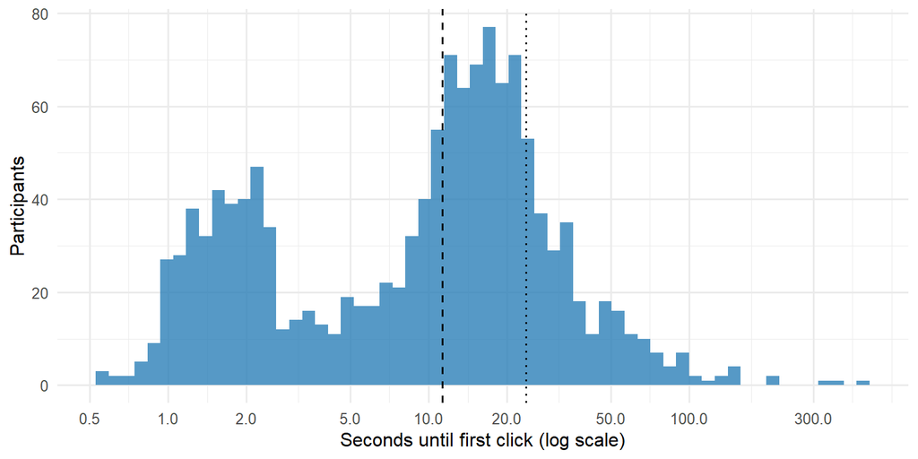

Figure 6: Seconds until the first click on the WTP page (log scale). The dashed line is the skimming cutoff (about 11 seconds); the dotted line is average reading time (about 23 seconds).

Table 14: Participants flagged as too fast, by condition.

| Condition | n | First click < skim cutoff | Page submit < skim cutoff | Median WTP, fast submitters | Median WTP, everyone else |
| --- | --- | --- | --- | --- | --- |
| Physical × Lifetime | 337 | 163 (48.4%) | 19 (5.6%) | $20 | $25 |
| Physical × Legacy | 333 | 170 (51.1%) | 23 (6.9%) | $25 | $25 |
| Digital × Lifetime | 329 | 145 (44.1%) | 17 (5.2%) | $20 | $20 |
| Digital × Legacy | 333 | 149 (44.7%) | 12 (3.6%) | $22.50 | $25 |

Table 15: Median seconds on the WTP page by condition (participants with at least one click).

| Condition | n | First click | Last click | Page submit | Median clicks |
| --- | --- | --- | --- | --- | --- |
| Physical × Lifetime | 335 | 11.2 | 14.8 | 22.4 | 1 |
| Physical × Legacy | 330 | 11.1 | 17.1 | 25.3 | 1 |
| Digital × Lifetime | 327 | 12.1 | 17.1 | 23.5 | 1 |
| Digital × Legacy | 332 | 13.2 | 18.5 | 25.0 | 1 |

Table 16: Tests of timing differences. A 2×2 ANOVA on log seconds (timing data are right-skewed), with a Kruskal–Wallis rank test across the four conditions as a check. The ratio compares typical (geometric-mean) times in the legacy vs. lifetime conditions.

| Measure | Frame: legacy ÷ lifetime | p (frame) | p (good) | p (good × frame) | p (Kruskal–Wallis, 4 groups) |
| --- | --- | --- | --- | --- | --- |
| Last click | 1.23 | < .001 | .056 | .977 | < .001 |
| Page submit | 1.14 | < .001 | .207 | .577 | .003 |

# Appendix: how the interaction tests are computed

This appendix walks through the two interaction tests in Table 5 using the study’s own numbers. Both start from the four groups: **PL** = physical × lifetime, **PG** = physical × legacy, **DL** = digital × lifetime, **DG** = digital × legacy.

## The ANOVA interaction (on ln(WTP + 1))

**Step 1: Transform each answer.** Each WTP becomes ln(WTP + 1), the natural log of WTP plus one. The +1 keeps $0 answers usable, since the log of 0 is undefined. The log shrinks large answers ($500 becomes 6.2, $25 becomes 3.3, $5 becomes 1.8), so a few very large answers cannot dominate an average.

**Step 2: Average the transformed values in each group.**

Table 17: Mean of ln(WTP + 1) in each group, and the same value converted back to dollars (‘typical WTP’).

| Group | n | Mean of ln(WTP + 1) | Typical WTP |
| --- | --- | --- | --- |
| PL: physical × lifetime | 337 | 3.200 | $23.54 |
| PG: physical × legacy | 333 | 3.430 | $29.88 |
| DL: digital × lifetime | 329 | 2.863 | $16.51 |
| DG: digital × legacy | 333 | 3.273 | $25.38 |

**Step 3: The physical–digital gap within each frame.**

- Lifetime gap = PL − DL = 3.200 − 2.863 = **0.338**, so physical is about 40% higher.
- Legacy gap = PG − DG = 3.430 − 3.273 = **0.157**, so physical is about 17% higher.

A difference of *x* in natural logs converts to a percentage difference of e^*x* − 1. Strictly, the percentage applies to WTP + 1, but with typical answers of $15–$30 the +1 makes little difference.

**Step 4: The interaction is the difference between the two gaps:** 0.338 − 0.157 = **0.180**. This “difference of differences” measures how much the physical premium shrank under the legacy frame.

**Step 5: Measure the noise.** People within the same group differ a lot (pooled standard deviation = 0.961 log units). Combining the uncertainty of all four group averages, the standard error of the interaction is 0.105. That is how much the estimate would typically vary if the study were repeated with new participants.

**Step 6: Signal ÷ noise.** *t* = 0.180 ÷ 0.105 = **1.71** (the *F* in the ANOVA table is *t*² = 2.93), giving *p* .087.

## The rank-based interaction

This test never averages dollar amounts. It only asks: **in a head-to-head matchup, who offered more?**

**Step 1: Pair everyone up.** Compare every person in one group with every person in the other, and count how often the first group “wins.” Ties count as half a win. The result is the probability of superiority (PS).

*Toy example.* Physical buyers offered $10, $25, and $50; digital buyers offered $5, $25, and $30. That makes 3 × 3 = 9 matchups:

|  | vs. $5 | vs. $25 | vs. $30 |
| --- | --- | --- | --- |
| **$10** | win | lose | lose |
| **$25** | win | tie | lose |
| **$50** | win | win | win |

Five wins and one tie: PS = (5 + 0.5) ÷ 9 = **61%**. Only the *order* matters. $50 beating $30 counts the same as $500 beating $30 would, which is why extreme answers cannot dominate.

**Step 2: Compute PS within each frame.**

- **Lifetime** (PL vs. DL, 110,873 matchups): physical wins 56.5% and ties 9.4%, so **PS = 61.2%**.
- **Legacy** (PG vs. DG): physical wins 49.8% and ties 9.0%, so **PS = 54.3%**.

The many ties come from people answering round numbers.

**Step 3: The interaction is the difference between the two PS values:** 61.2% − 54.3% = **6.9 percentage points**. Physical buyers’ head-to-head advantage over digital buyers dropped by this much under the legacy frame.

**Step 4: Measure the noise.** Each PS has its own standard error, computed with the DeLong method. Each person gets a score for the share of the other group they beat, and the more those scores vary, the less certain the PS. Here the lifetime SE is 2.16 points and the legacy SE is 2.22 points. The two frames involve different people, so their uncertainties combine as √(2.16² + 2.22²) = **3.10 points**.

**Step 5: Signal ÷ noise.** *z* = 6.89 ÷ 3.10 = **2.22**, giving *p* .026.

## Why the two tests can disagree

They measure the interaction in different units.

- **The ANOVA** asks whether physical’s **percentage premium** in typical WTP shrank (from about 40% to 17%). The *size* of differences matters, so variation among large answers adds noise.
- **The rank-based test** asks whether physical buyers’ **chance of outbidding** digital buyers dropped (from 61.2% to 54.3%). Only who outbid whom matters.

Here both point the same way, but the change looked clearer on the rank scale.

**Why not raw dollars?** On the raw dollar scale there is essentially no interaction. The legacy frame added a similar *dollar* amount to both photos: average WTP rose from $26.47 to $40.77 for digital and from $34.80 to $47.55 for physical. So the dollar gap barely moved ($8.32 vs. $6.78). In *relative* terms, though, digital rose much more because it started lower (+54% vs. +37%). Whether the interaction exists therefore depends on whether “the gap” is measured in dollars or in relative terms. This report uses relative measures (log and rank), because the research question is about how the two formats are valued *compared with each other*, and “physical is worth 40% more” is more meaningful across products and price levels than “physical is worth $8 more.”

# Appendix: coding procedure

The codebook given to every coder (verbatim) defined these codes:

- **quality**: `ok` (gives a reason, even briefly), `low_effort` (generic, no reason, e.g. “seems reasonable”), `off_topic` (does not address the question, nonsensical, gibberish).
- **misread_format**: the text shows the person believed they would receive the *other* format (or both). Contrasts such as “it’s not even a printed copy” do not count.
- **rejects_premise**: refuses the scenario or says it does not apply to them.
- **wtp_text_conflict**: the text clearly contradicts the WTP entered (e.g., “I’d pay $15–20” but entered $10). Mentioning other amounts as comparisons does not count.
- **sensitive**: personal or distressing disclosures.
- **themes**: zero or more of the ten themes shown in Figure 5.

Coders were told to choose `ok`/`no` when in doubt, so the flags are deliberately conservative. Codes are saved in wtp_explain_coding.csv (second-coder codes in wtp_explain_coding_reliability.csv), and the full codebook is in `wtp_explain_codebook.md`, all alongside this report.